# DATA606 LAB3 Probability

Farhod Ibragimov

## The Hot Hand

Basketball players who make several baskets in succession are described as having a *hot hand*. Fans and players have long believed in the hot hand phenomenon, which refutes the assumption that each shot is independent of the next. However, [a 1985 paper](http://www.sciencedirect.com/science/article/pii/0010028585900106) by Gilovich, Vallone, and Tversky collected evidence that contradicted this belief and showed that successive shots are independent events. This paper started a great controversy that continues to this day, as you can see by Googling *hot hand basketball*.

We do not expect to resolve this controversy today. However, in this lab we’ll apply one approach to answering questions like this. The goals for this lab are to (1) think about the effects of independent and dependent events, (2) learn how to simulate shooting streaks in R, and (3) to compare a simulation to actual data in order to determine if the hot hand phenomenon appears to be real.

## Getting Started

### Load packages

In this lab, we will explore and visualize the data using the `tidyverse` suite of packages. The data can be found in the companion package for OpenIntro labs, **openintro**.

Let’s load the packages.

```r
library(tidyverse)
library(openintro)
```

### Data

Your investigation will focus on the performance of one player: [Kobe Bryant](https://en.wikipedia.org/wiki/Kobe_Bryant) of the Los Angeles Lakers. His performance against the Orlando Magic in the [2009 NBA Finals](https://en.wikipedia.org/wiki/2009_NBA_Finals) earned him the title *Most Valuable Player* and many spectators commented on how he appeared to show a hot hand. The data file we’ll use is called `kobe_basket`.

```r
glimpse(kobe_basket)
```

```
## Rows: 133
## Columns: 6
## $ vs          <fct> ORL, ORL, ORL, ORL, ORL, ORL, ORL, ORL, ORL, ORL, ORL, ORL…
## $ game        <int> 1, 1, 1, 1, 1, 1, 1, 1, 1, 1, 1, 1, 1, 1, 1, 1, 1, 1, 1, 1…
## $ quarter     <fct> 1, 1, 1, 1, 1, 1, 1, 1, 1, 2, 2, 2, 2, 2, 2, 2, 2, 2, 3, 3…
## $ time        <fct> 9:47, 9:07, 8:11, 7:41, 7:03, 6:01, 4:07, 0:52, 0:00, 6:35…
## $ description <fct> Kobe Bryant makes 4-foot two point shot, Kobe Bryant misse…
## $ shot        <chr> "H", "M", "M", "H", "H", "M", "M", "M", "M", "H", "H", "H"…
```

```r
set.seed(1212)
```

This data frame contains 133 observations and 6 variables, where every row records a shot taken by Kobe Bryant. The `shot` variable in this dataset indicates whether the shot was a hit (`H`) or a miss (`M`).

Just looking at the string of hits and misses, it can be difficult to gauge whether or not it seems like Kobe was shooting with a hot hand. One way we can approach this is by considering the belief that hot hand shooters tend to go on shooting streaks. For this lab, we define the length of a shooting streak to be the *number of consecutive baskets made until a miss occurs*.

For example, in Game 1 Kobe had the following sequence of hits and misses from his nine shot attempts in the first quarter:

$$\textrm{H M | M | H H M | M | M | M}$$

You can verify this by viewing the first 9 rows of the data in the data viewer.

Within the nine shot attempts, there are six streaks, which are separated by a “|” above. Their lengths are one, zero, two, zero, zero, zero (in order of occurrence).

1. What does a streak length of 1 mean, i.e. how many hits and misses are in a streak of 1? What about a streak length of 0?

**Insert your answer here**

Farhod’s answer:

Streak length of 1 means that there are 1 hit and 1 miss in the streak. Streak length of 0 means that there are 0 hits and 1 miss, i.e. player had only one shot and it was a miss.

End of answer.

Counting streak lengths manually for all 133 shots would get tedious, so we’ll use the custom function `calc_streak` to calculate them, and store the results in a data frame called `kobe_streak` as the `length` variable.

```r
kobe_streak <- calc_streak(kobe_basket$shot)
```

We can then take a look at the distribution of these streak lengths.

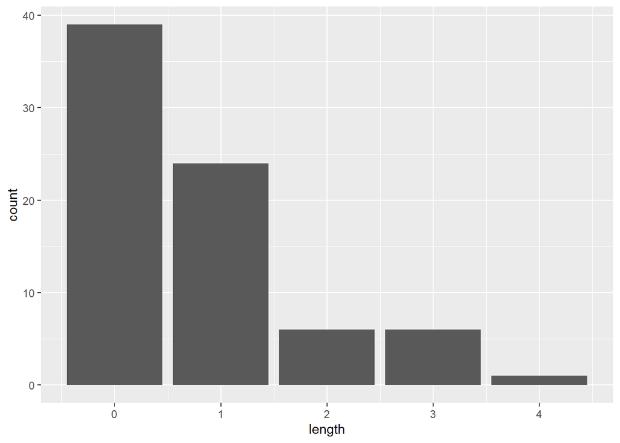

```r
ggplot(data = kobe_streak, aes(x = length)) +
  geom_bar()
```

2. Describe the distribution of Kobe’s streak lengths from the 2009 NBA finals. What was his typical streak length? How long was his longest streak of baskets? Make sure to include the accompanying plot in your answer.

**Insert your answer here**

Farhod’s answer:

This code shows statistic summary for `kobe_streak length`variable:

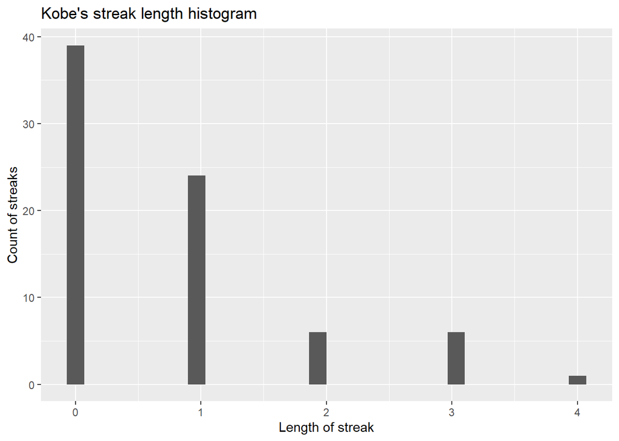

```r
ggplot(kobe_streak, aes(x = length)) +
  geom_histogram() +
  labs(title = "Kobe's streak length histogram",
       x = "Length of streak",
       y = "Count of streaks")
```

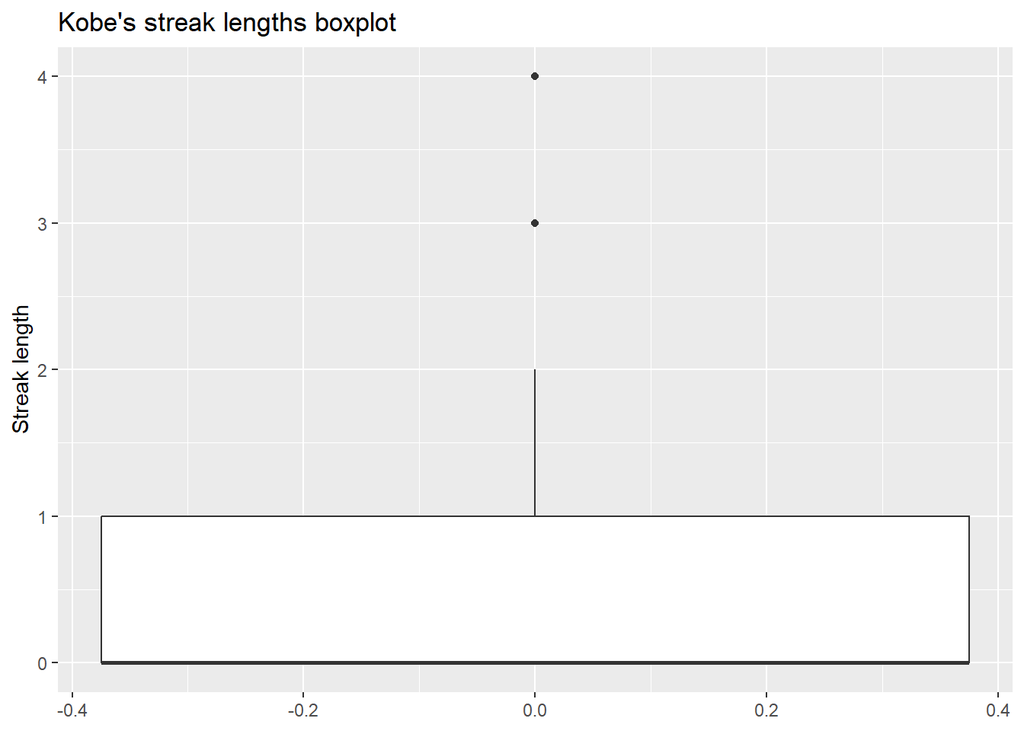

```r
ggplot(kobe_streak, aes(y = length)) +
  geom_boxplot() +
  labs(title = "Kobe's streak lengths boxplot",
       y = "Streak length")
```

```r
print(summary(kobe_streak$length))
```

```
##    Min. 1st Qu.  Median    Mean 3rd Qu.    Max.
##  0.0000  0.0000  0.0000  0.7632  1.0000  4.0000
```

```r
max(kobe_streak$length)
```

```
## [1] 4
```

Median value gives an idea that Kobe’s typical streak length is 0.

His longest streak of baskets is 4, equals to max value from statistic summary printed above.

From histogram and boxplot I can say that distribution is unimodal and skewed to the right with most streak lengths are 0 and 1. Outliers indicate that Kobe’s streaks of 3 and 4 baskets are usually rare. The histogram also shows that Kobe’s typical streak length is 0, since most occurred streaks (mode) has length of 0.

End of answer.

## Compared to What?

We’ve shown that Kobe had some long shooting streaks, but are they long enough to support the belief that he had a hot hand? What can we compare them to?

To answer these questions, let’s return to the idea of *independence*. Two processes are independent if the outcome of one process doesn’t effect the outcome of the second. If each shot that a player takes is an independent process, having made or missed your first shot will not affect the probability that you will make or miss your second shot.

A shooter with a hot hand will have shots that are *not* independent of one another. Specifically, if the shooter makes his first shot, the hot hand model says he will have a *higher* probability of making his second shot.

Let’s suppose for a moment that the hot hand model is valid for Kobe. During his career, the percentage of time Kobe makes a basket (i.e. his shooting percentage) is about 45%, or in probability notation,

$$P(\textrm{shot 1 = H}) = 0.45$$

If he makes the first shot and has a hot hand (*not* independent shots), then the probability that he makes his second shot would go up to, let’s say, 60%,

$$P(\textrm{shot 2 = H} \, | \,
\textrm{shot 1 = H}) = 0.60$$

As a result of these increased probabilites, you’d expect Kobe to have longer streaks. Compare this to the skeptical perspective where Kobe does *not* have a hot hand, where each shot is independent of the next. If he hit his first shot, the probability that he makes the second is still 0.45.

$$P(\textrm{shot 2 = H} \, | \,
\textrm{shot 1 = H}) = 0.45$$

In other words, making the first shot did nothing to effect the probability that he’d make his second shot. If Kobe’s shots are independent, then he’d have the same probability of hitting every shot regardless of his past shots: 45%.

Now that we’ve phrased the situation in terms of independent shots, let’s return to the question: how do we tell if Kobe’s shooting streaks are long enough to indicate that he has a hot hand? We can compare his streak lengths to someone without a hot hand: an independent shooter.

## Simulations in R

While we don’t have any data from a shooter we know to have independent shots, that sort of data is very easy to simulate in R. In a simulation, you set the ground rules of a random process and then the computer uses random numbers to generate an outcome that adheres to those rules. As a simple example, you can simulate flipping a fair coin with the following.

```r
coin_outcomes <- c("heads", "tails")
sample(coin_outcomes, size = 1, replace = TRUE)
```

```
## [1] "tails"
```

The vector `coin_outcomes` can be thought of as a hat with two slips of paper in it: one slip says `heads` and the other says `tails`. The function `sample` draws one slip from the hat and tells us if it was a head or a tail.

Run the second command listed above several times. Just like when flipping a coin, sometimes you’ll get a heads, sometimes you’ll get a tails, but in the long run, you’d expect to get roughly equal numbers of each.

If you wanted to simulate flipping a fair coin 100 times, you could either run the function 100 times or, more simply, adjust the `size` argument, which governs how many samples to draw (the `replace = TRUE` argument indicates we put the slip of paper back in the hat before drawing again). Save the resulting vector of heads and tails in a new object called `sim_fair_coin`.

```r
sim_fair_coin <- sample(coin_outcomes, size = 100, replace = TRUE)
```

To view the results of this simulation, type the name of the object and then use `table` to count up the number of heads and tails.

```r
sim_fair_coin
```

```
##   [1] "tails" "heads" "heads" "tails" "tails" "tails" "tails" "heads" "tails"
##  [10] "heads" "heads" "heads" "tails" "tails" "heads" "heads" "heads" "tails"
##  [19] "heads" "heads" "tails" "heads" "tails" "tails" "tails" "heads" "tails"
##  [28] "heads" "tails" "heads" "tails" "heads" "tails" "tails" "heads" "tails"
##  [37] "tails" "tails" "heads" "heads" "tails" "tails" "heads" "tails" "heads"
##  [46] "tails" "heads" "heads" "heads" "tails" "heads" "tails" "tails" "tails"
##  [55] "tails" "tails" "tails" "tails" "heads" "heads" "heads" "tails" "heads"
##  [64] "tails" "heads" "heads" "heads" "tails" "heads" "heads" "heads" "tails"
##  [73] "tails" "tails" "tails" "tails" "heads" "tails" "heads" "tails" "tails"
##  [82] "tails" "tails" "heads" "tails" "heads" "tails" "tails" "tails" "tails"
##  [91] "heads" "tails" "heads" "tails" "tails" "tails" "tails" "heads" "heads"
## [100] "heads"
```

```r
table(sim_fair_coin)
```

```
## sim_fair_coin
## heads tails
##    44    56
```

Since there are only two elements in `coin_outcomes`, the probability that we “flip” a coin and it lands heads is 0.5. Say we’re trying to simulate an unfair coin that we know only lands heads 20% of the time. We can adjust for this by adding an argument called `prob`, which provides a vector of two probability weights.

```r
sim_unfair_coin <- sample(coin_outcomes, size = 100, replace = TRUE,
                          prob = c(0.2, 0.8))
```

`prob=c(0.2, 0.8)` indicates that for the two elements in the `outcomes` vector, we want to select the first one, `heads`, with probability 0.2 and the second one, `tails` with probability 0.8. Another way of thinking about this is to think of the outcome space as a bag of 10 chips, where 2 chips are labeled “head” and 8 chips “tail”. Therefore at each draw, the probability of drawing a chip that says “head”” is 20%, and “tail” is 80%.

3. In your simulation of flipping the unfair coin 100 times, how many flips came up heads? Include the code for sampling the unfair coin in your response. Since the markdown file will run the code, and generate a new sample each time you *Knit* it, you should also “set a seed” **before** you sample. Read more about setting a seed below.

**Insert your answer here**

Farhod’s answer:

```r
set.seed(178)
coin_outcomes <- c("heads", "tails")
sim_unfair_coin <- sample(coin_outcomes, size = 100, replace = TRUE,
                          prob = c(0.2, 0.8))
table(sim_unfair_coin)
```

```
## sim_unfair_coin
## heads tails
##    25    75
```

The code above shows that 25 flips came up heads from flipping unfair coin 100 times. Its probability $P(heads) = 25 / 100 = 0.25$ close to the probablity 0.2 set for “heads” in the code.

End of answer.

**A note on setting a seed:** Setting a seed will cause R to select the same sample each time you knit your document. This will make sure your results don’t change each time you knit, and it will also ensure reproducibility of your work (by setting the same seed it will be possible to reproduce your results). You can set a seed like this:

```r
set.seed(35797)                 # make sure to change the seed
```

The number above is completely arbitraty. If you need inspiration, you can use your ID, birthday, or just a random string of numbers. The important thing is that you use each seed only once in a document. Remember to do this **before** you sample in the exercise above.

In a sense, we’ve shrunken the size of the slip of paper that says “heads”, making it less likely to be drawn, and we’ve increased the size of the slip of paper saying “tails”, making it more likely to be drawn. When you simulated the fair coin, both slips of paper were the same size. This happens by default if you don’t provide a `prob` argument; all elements in the `outcomes` vector have an equal probability of being drawn.

If you want to learn more about `sample` or any other function, recall that you can always check out its help file.

```r
?sample
```

## Simulating the Independent Shooter

Simulating a basketball player who has independent shots uses the same mechanism that you used to simulate a coin flip. To simulate a single shot from an independent shooter with a shooting percentage of 50% you can type

```r
shot_outcomes <- c("H", "M")
sim_basket <- sample(shot_outcomes, size = 1, replace = TRUE)
```

To make a valid comparison between Kobe and your simulated independent shooter, you need to align both their shooting percentage and the number of attempted shots.

4. What change needs to be made to the `sample` function so that it reflects a shooting percentage of 45%? Make this adjustment, then run a simulation to sample 133 shots. Assign the output of this simulation to a new object called `sim_basket`.

**Insert your answer here**

Farhod’s answer:

To reflect a shooting percentage of 45% and simulate 133 shots, we need to set `prob = c(0.45, 0.55)` and `size = 133` in the `sample` function.

```r
set.seed(125)
shot_outcomes <- c("H", "M")
sim_basket <- sample(shot_outcomes,
                     size = 133,
                     replace = TRUE,
                     prob = c(0.45, 0.55)
                     )
table(sim_basket)
```

```
## sim_basket
##  H  M
## 64 69
```

Here we can see that hits (H) count is 64 and its probability is $P(H) = 64 /133 = 0.48$ and it is close to probability 0.45.

End of answer.

Note that we’ve named the new vector `sim_basket`, the same name that we gave to the previous vector reflecting a shooting percentage of 50%. In this situation, R overwrites the old object with the new one, so always make sure that you don’t need the information in an old vector before reassigning its name.

With the results of the simulation saved as `sim_basket`, you have the data necessary to compare Kobe to our independent shooter.

Both data sets represent the results of 133 shot attempts, each with the same shooting percentage of 45%. We know that our simulated data is from a shooter that has independent shots. That is, we know the simulated shooter does not have a hot hand.

## More Practice

### Comparing Kobe Bryant to the Independent Shooter

5. Using `calc_streak`, compute the streak lengths of `sim_basket`, and save the results in a data frame called `sim_streak`.

**Insert your answer here**

Farhod’s answer:

This code cell computes the streak lengths for simulated shooter:

```r
set.seed(154)
sim_streak <- calc_streak(sim_basket)
```

End of answer.

6. Describe the distribution of streak lengths. What is the typical streak length for this simulated independent shooter with a 45% shooting percentage? How long is the player’s longest streak of baskets in 133 shots? Make sure to include a plot in your answer.

**Insert your answer here**

Farhod’s answer:

This code creates a histogram and boxplot for simulated shooter’s streak:

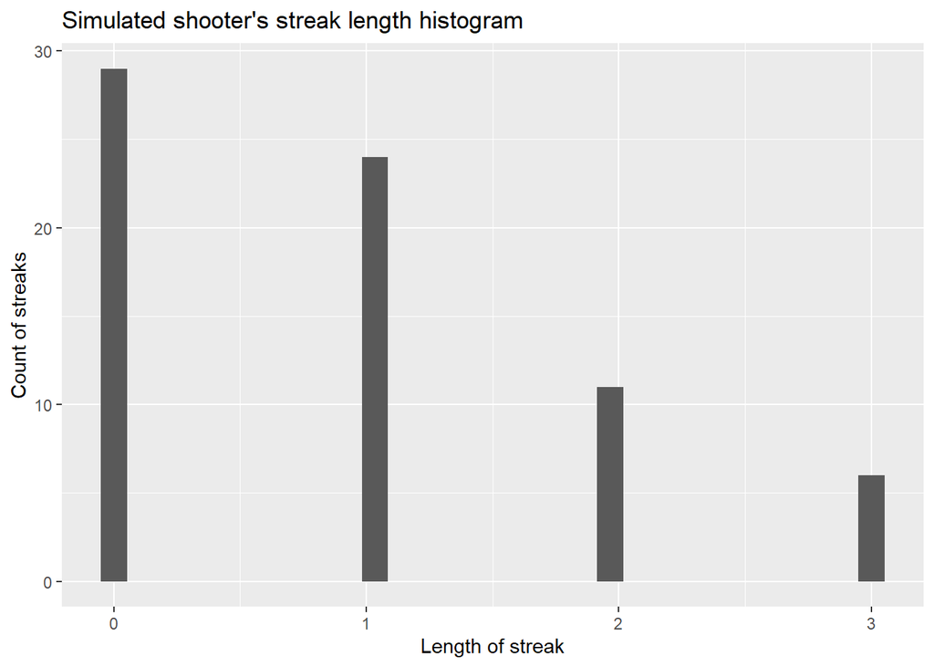

```r
ggplot(sim_streak, aes(x = length)) +
  geom_histogram() +
  labs(title = "Simulated shooter's streak length histogram",
       x = "Length of streak",
       y = "Count of streaks")
```

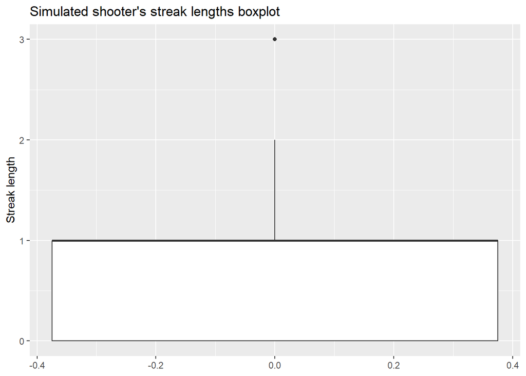

```r
ggplot(sim_streak, aes(y = length)) +
  geom_boxplot() +
  labs(title = "Simulated shooter's streak lengths boxplot",
       y = "Streak length")
```

```r
print(summary(sim_streak$length))
```

```
##    Min. 1st Qu.  Median    Mean 3rd Qu.    Max.
##  0.0000  0.0000  1.0000  0.9143  1.0000  3.0000
```

The histogram indicates that most streaks are 0 and 1, and the distribution is unimodal and skewed to the right. The statistic summary shows that the median streak length is 1, and the longest streak is 3. Since median streak length is 1, it is the typical streak length for simulated shooter.

End of answer.

7. If you were to run the simulation of the independent shooter a second time, how would you expect its streak distribution to compare to the distribution from the question above? Exactly the same? Somewhat similar? Totally different? Explain your reasoning.

**Insert your answer here**

Farhod’s answer:

If I run the simulation second time, I would expect its streak distribution to be somewhat similar to the first one. This is because each simulated shooter’s shot is independent event in the code above, i.e. previous shot’s outcome has no effect on the outcome of the next shot. Another reason is that probability of hit set to 0.45 and shots amount set to 133 on each separate simulation run. Shape of distribution also will be somewhat similar, unimodal and skewed to the right.

End of answer.

8. How does Kobe Bryant’s distribution of streak lengths compare to the distribution of streak lengths for the simulated shooter? Using this comparison, do you have evidence that the hot hand model fits Kobe’s shooting patterns? Explain.

**Insert your answer here**

Farhod’s answer:

Let’s visualize Kobe’s and simulated shooter’s histograms:

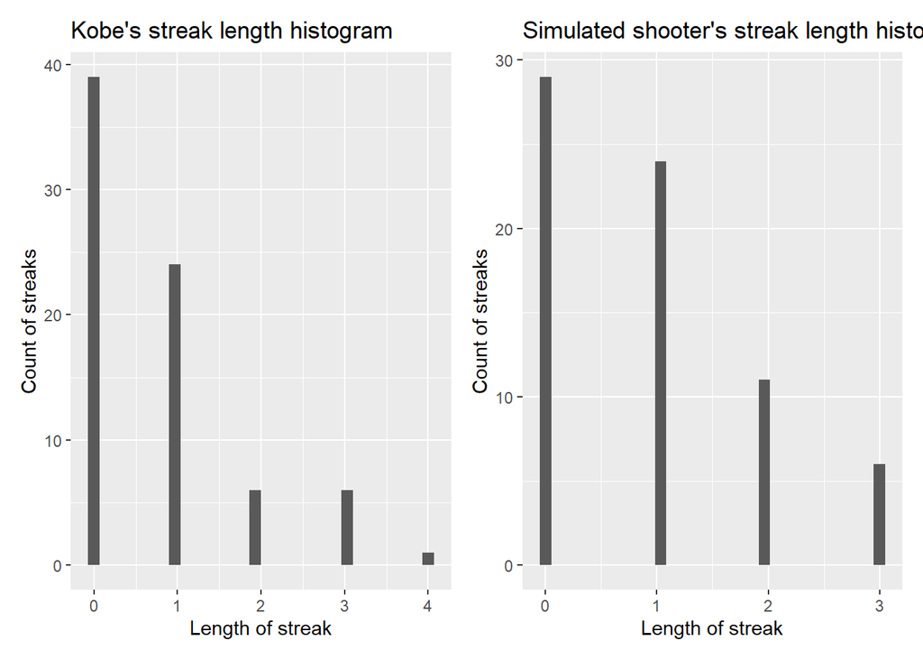

```r
kobes_histogram <- ggplot(kobe_streak, aes(x = length)) +
  geom_histogram() +
  labs(title = "Kobe's streak length histogram",
       x = "Length of streak",
       y = "Count of streaks")

simulation_histogram <- ggplot(sim_streak, aes(x = length)) +
  geom_histogram() +
  labs(title = "Simulated shooter's streak length histogram",
       x = "Length of streak",
       y = "Count of streaks")

kobes_histogram | simulation_histogram
```

Kobe’s streaks statistic summary:

```r
print(summary(kobe_streak))
```

```
##      length
##  Min.   :0.0000
##  1st Qu.:0.0000
##  Median :0.0000
##  Mean   :0.7632
##  3rd Qu.:1.0000
##  Max.   :4.0000
```

Simulated shooter’s statistic summary:

```r
print(summary(sim_streak))
```

```
##      length
##  Min.   :0.0000
##  1st Qu.:0.0000
##  Median :1.0000
##  Mean   :0.9143
##  3rd Qu.:1.0000
##  Max.   :3.0000
```

From these plots I can see Kobe’s and simulated shooter’s distributions of streaks are somewhat similar. Both distributions has majority of streak lengths 0 or 1. Both distributions are unimodal and right-skewed. Kobe’s longest streak is 4, while simulated shooter’s longest streak is 3. Kobe’s distribution median is 0, simulated shooter’s median is 1.

Let’s make mathematical calculations for probabilities of independent events with formula
$$P(A andB) = P(A) *
P(B)$$

Probability of streak length of 1 is:
$$P(HIT) = 0.45$$

Probability of streak length of 2 is:

$$P(HIT1andHIT2) = 0.45 * 0.45 = 0.2025$$

We can see that probability decreases when streak length increases. Because of that, distribution histograms also showing decrease of streak counts with longer lengths. And it explains why distributions are right-skewed.

According to “hot hand” model, probability of making a hit increases after previous successful hit. And that would make the distribution histograms show a higher frequency of longer streaks and shape of distribution would be left-skewed. This is opposite to what we see in Kobe’s and simulated shooter’s histograms, where distribuations are right-skewed because of decreasing probability as I mentioned earlier.

Conclusion:

I can say from above analyses that “hot hand” theory doesn’t fit Kobe’s pattern and it appears that Kobe’s shots are independent events.

End of answer.